# Analytik Jena sensors

Use case simulations and comparisons

Pedro J. Aphalo

2022-12-07

## Setup

All packages used can be installed from CRAN. However, the version of ‘photobiologySensors’ that includes data for the Analytik Jena is at the moment under development and available from GitHub. I will submit the updated version to CRAN in a few days. I will let you know when it has been accepted.

We load the packages and set photon units as the default.

```r
library(photobiologySensors)
library(photobiologyLamps)
library(photobiologyFilters)

library(ggspectra)
photon_as_default()
```

## Sensors on their own

The numbers in the bars at the top of the plots indicate the proportion of photons being sensed from UV-B and UV-A in each condition. The square brackets next to the name of a waveband indicate that the spectral data do not cover the whole range of the waveband. In this case this should make little difference as we can assume that the sensors are not responding much to photons from outside the range shown in the figures in the manual of the instrument and sensors.

Digitized from manual assuming that energy response is shown in the figures, and plotted as photon response normalized to the wavelength of maximum sensitivity.

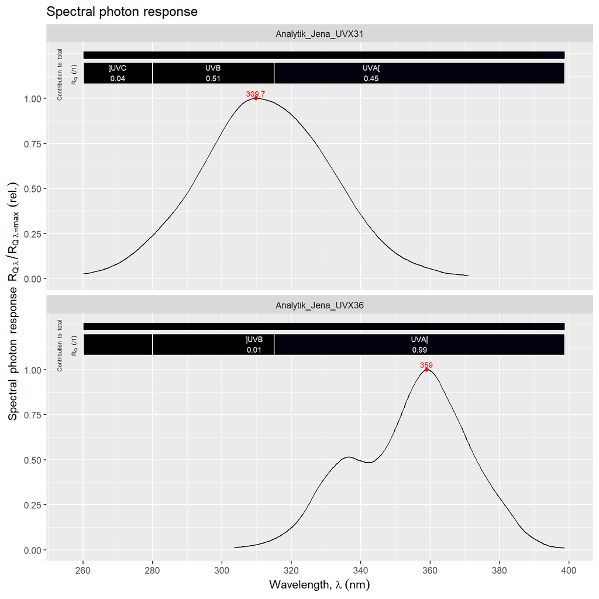

```r
autoplot(sensors.mspct[c("Analytik_Jena_UVX31", "Analytik_Jena_UVX36")],
         facets = 1) +
  ggtitle("Spectral photon response")
```

## Sensors in sunlight

By combining the sensor response with a photon irradiance spectrum of sunlight for mid morning in Helsinki, we see that UVX-36 might work with a sunlight specific calibration but the UVX-31 could be calibrated for an approximate measurement of UV-A but is useless for UV-B in sunlight.

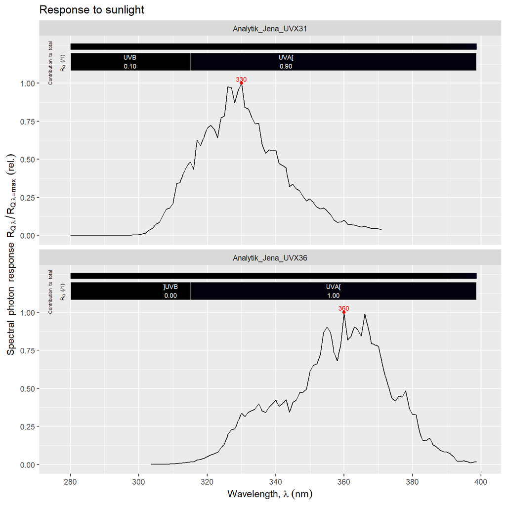

```r
autoplot(convolve_each(sensors.mspct[c("Analytik_Jena_UVX31", "Analytik_Jena_UVX36")], sun.spct),
         facets = 1) +
  ggtitle("Response to sunlight")
```

## Sensors with broad-band UV-B lamps

As we can expect that the spectrum of the radiation from the lamps varies little or not a all, the sensors could be calibrated to be useful. Anyway, they would require separate calibrations for bare lamps, lamps filtered with cellulose diacetate and lamps filtered with polyester.

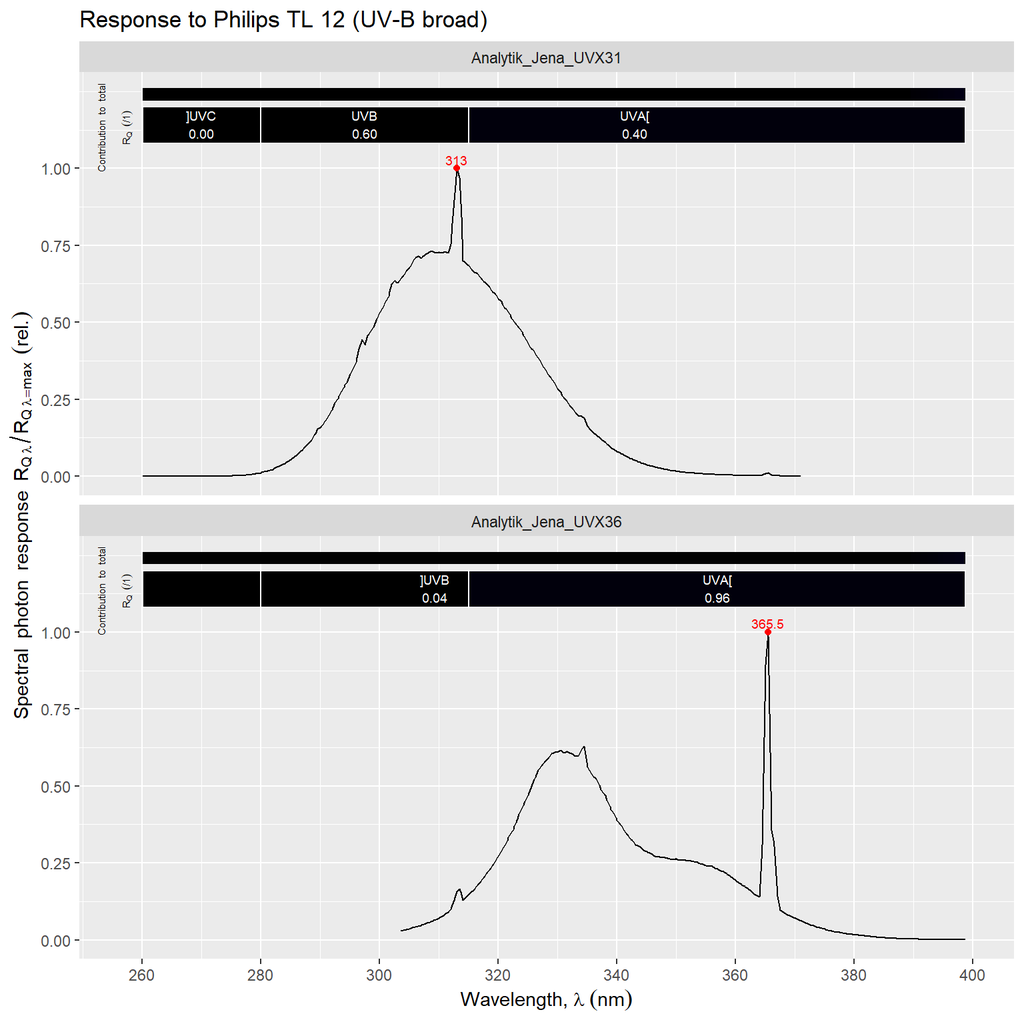

```r
autoplot(convolve_each(sensors.mspct[c("Analytik_Jena_UVX31", "Analytik_Jena_UVX36")],
                       lamps.mspct$Philips.FT.TL.40W.12.uv),
         facets = 1) +
  ggtitle("Response to Philips TL 12 (UV-B broad)")
```

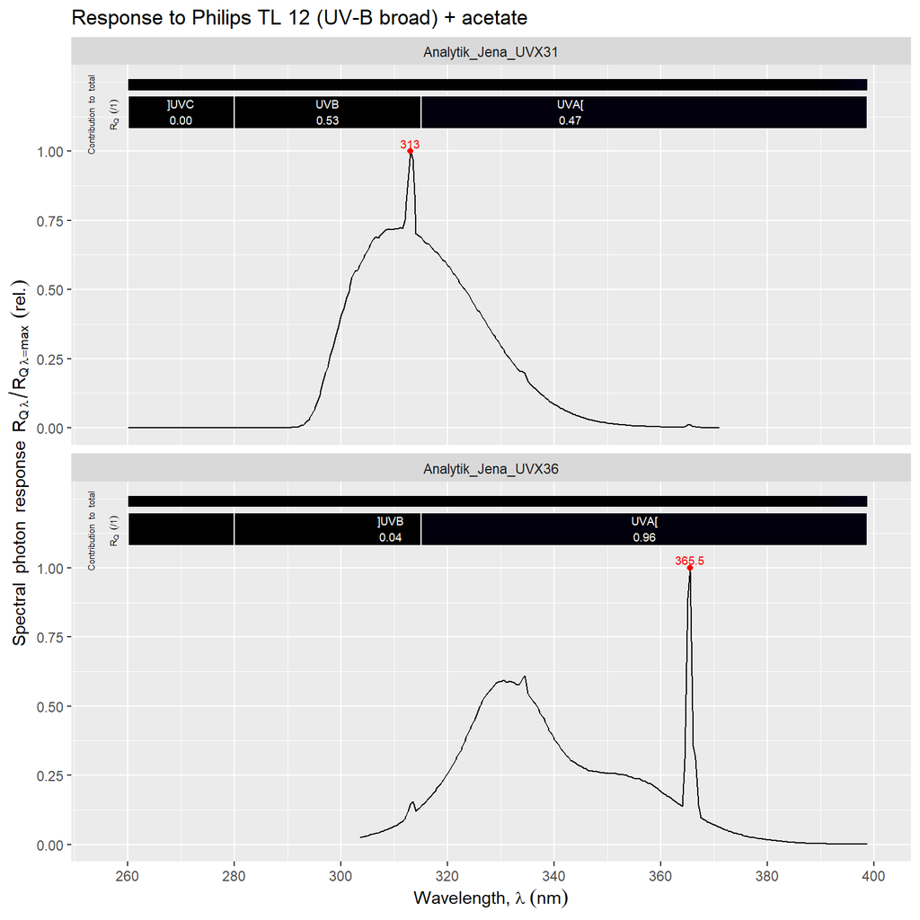

```r
autoplot(convolve_each(sensors.mspct[c("Analytik_Jena_UVX31", "Analytik_Jena_UVX36")],
                       (lamps.mspct$Philips.FT.TL.40W.12.uv * filters.mspct$Courtaulds_CA_115um)),
         facets = 1) +
  ggtitle("Response to Philips TL 12 (UV-B broad) + acetate")
```

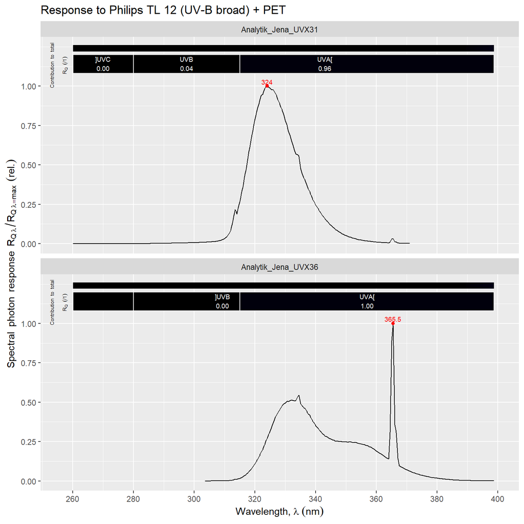

```r
autoplot(convolve_each(sensors.mspct[c("Analytik_Jena_UVX31", "Analytik_Jena_UVX36")],
                       (lamps.mspct$Philips.FT.TL.40W.12.uv * polyester.spct)),
         facets = 1) +
  ggtitle("Response to Philips TL 12 (UV-B broad) + PET")
```

## Sensors with narrow-band UV-B lamps

As we can expect that the spectrum of the radiation from the lamps varies little or not a all, the sensors could be calibrated to be useful. Anyway, they would require separate calibrations for bare lamps and lamps filtered with polyester.

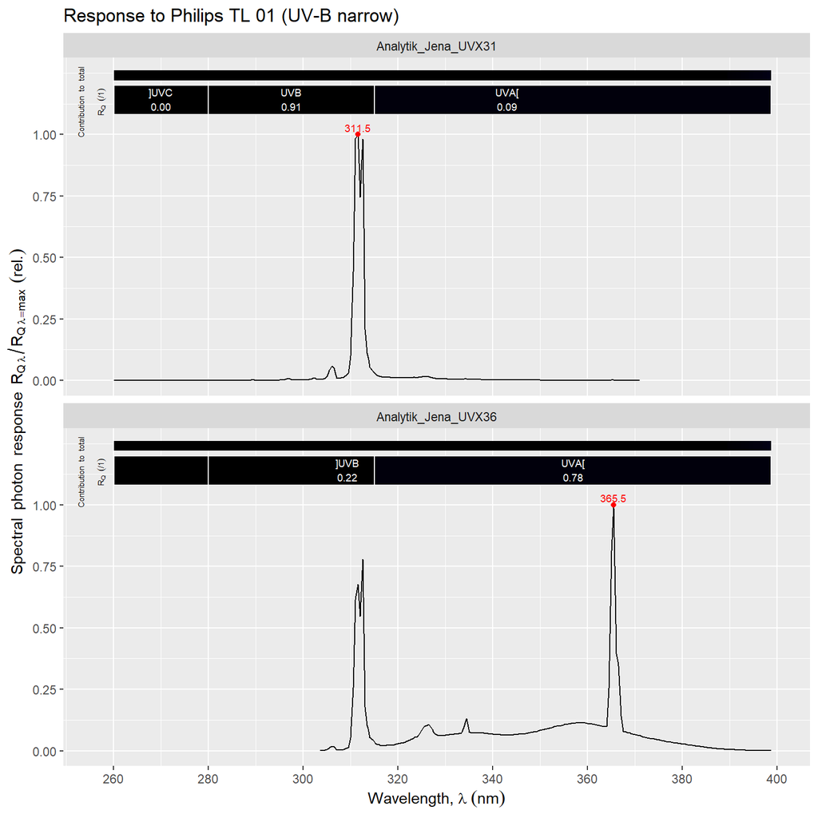

```r
autoplot(convolve_each(sensors.mspct[c("Analytik_Jena_UVX31", "Analytik_Jena_UVX36")],
                       lamps.mspct$Philips.FT.TL.40W.01.uv),
         facets = 1) +
  ggtitle("Response to Philips TL 01 (UV-B narrow)")
```

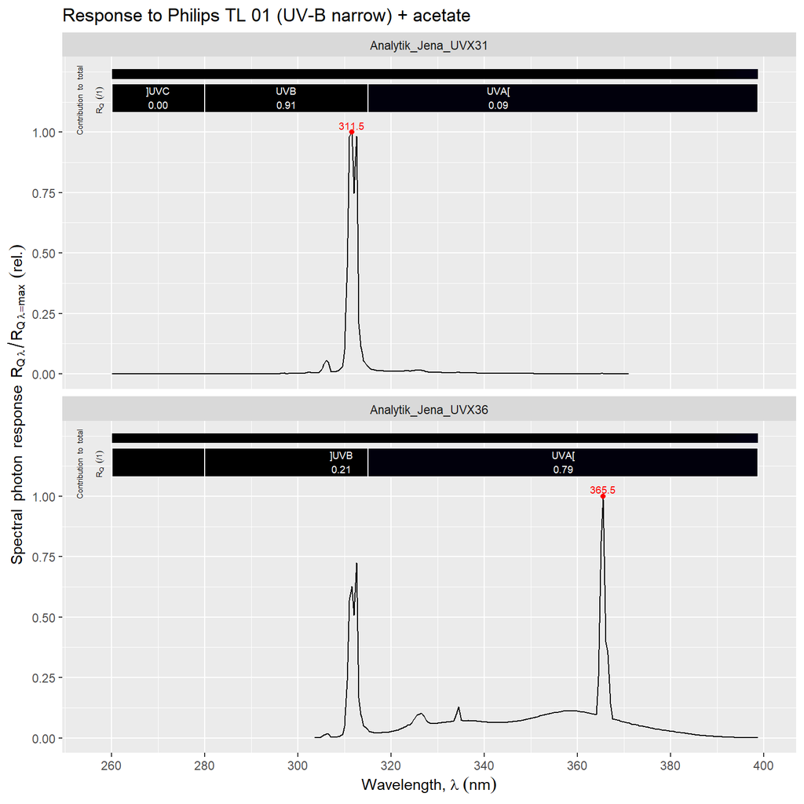

```r
autoplot(convolve_each(sensors.mspct[c("Analytik_Jena_UVX31", "Analytik_Jena_UVX36")],
                       (lamps.mspct$Philips.FT.TL.40W.01.uv * filters.mspct$Courtaulds_CA_115um)),
         facets = 1) +
  ggtitle("Response to Philips TL 01 (UV-B narrow) + acetate")
```

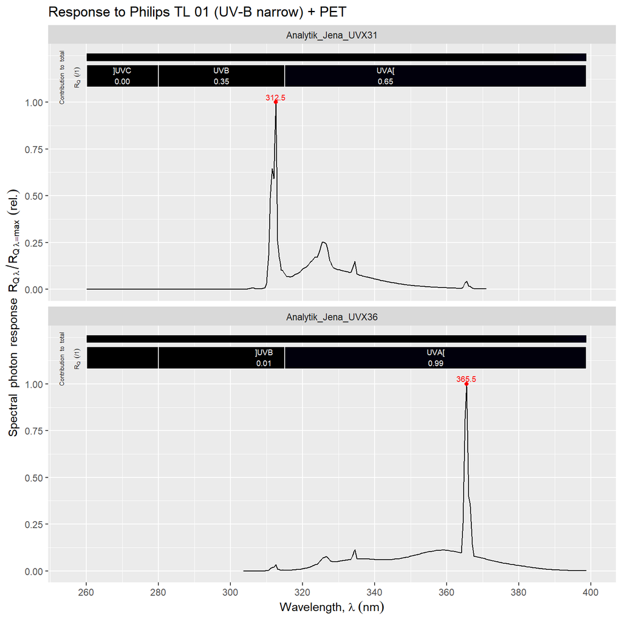

```r
autoplot(convolve_each(sensors.mspct[c("Analytik_Jena_UVX31", "Analytik_Jena_UVX36")],
                       (lamps.mspct$Philips.FT.TL.40W.01.uv * polyester.spct)),
         facets = 1) +
  ggtitle("Response to Philips TL 01 (UV-B narrow) + PET")
```

## Comparison with sglux and Kipp UV-B sensors

Sensors from different suppliers are very different!

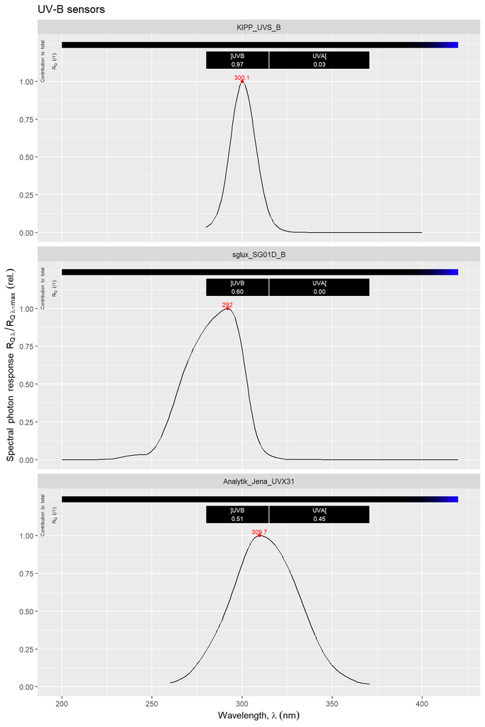

```r
autoplot(sensors.mspct[c("KIPP_UVS_B", "sglux_SG01D_B", "Analytik_Jena_UVX31")],
         facets = 1) +
  ggtitle("UV-B sensors")
```

## Comparison with sglux and Kipp UV-A sensors

Sensors from different suppliers are rather different, but I think they can be calibrated to work in sunlight. The sglux one, would not be good for UV-A LEDs or lamps emitting strongly in UV-A1, but on the other hand it is the only sensor I know that can be used to measure UV-A2, and used in combination with their Blue and UV-B sensors used to measure UV-B, UV-A1, UV-A2 and Blue light separately in sunlight.

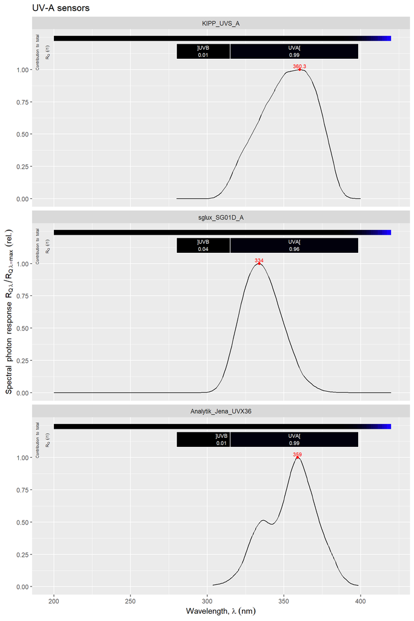

```r
autoplot(sensors.mspct[c("KIPP_UVS_A", "sglux_SG01D_A", "Analytik_Jena_UVX36")],
         facets = 1) +
  ggtitle("UV-A sensors")
```